# Stat5405 Homework 4

**Q3. (50 points)** Consider the ToothGrowth dataset from the R package *datasets*. The response is *len*, the length of odontoblasts (cells responsible for tooth growth) in 60 guinea pigs. Each animal received one of three dose levels of vitamin C (0.5, 1, and 2 mg/day) denoted as the factor *dose* (Factor A) by one of two delivery methods, orange juice or ascorbic acid (a form of vitamin C and coded as VC), denoted as the factor *supp* (Factor B).

```r
# Load the required dataset
data(ToothGrowth)

# View the structure of the dataset
str(ToothGrowth)
```

```
'data.frame':   60 obs. of  3 variables:
 $ len : num  4.2 11.5 7.3 5.8 6.4 10 11.2 11.2 5.2 7 ...
 $ supp: Factor w/ 2 levels "OJ","VC": 2 2 2 2 2 2 2 2 2 2 ...
 $ dose: num  0.5 0.5 0.5 0.5 0.5 0.5 0.5 0.5 0.5 0.5 ...
```

1. Fit and interpret a one-factor ANOVA model relating the response *len* to *dose* (Factor A).

Null Hypothesis: The mean length of odontoblasts is the same for all levels of dose.

$H_0$: $\mu_1 = \mu_2 = \mu_3$

where $\mu_i$ is the mean length of odontoblasts for level $i$ of dose.

Alternative Hypothesis: The mean length of odontoblasts is different for at least one level of dose.

$H_a$: $\mu_i \neq \mu_j$ for at least one pair of levels $i$ and $j$ of dose.

Assumptions (WILL BE VALIDATED AFTER RUNNING ANOVA MODEL):

Normality:

We assume that the length of odontoblasts for each level of dose is normally distributed.

Independence:

We assume that the length of odontoblasts for each level of dose is independent of the length of odontoblasts for the other levels of dose.

Equal Variance:

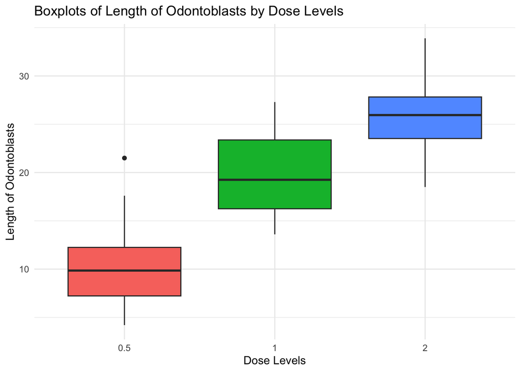

```r
# Create boxplots by dose levels using ggplot
ggplot(ToothGrowth, aes(x=as.factor(dose), y=len, fill=as.factor(dose))) +
    geom_boxplot(show.legend = FALSE) +
    labs(x="Dose Levels", y="Length of Odontoblasts") +
    theme_minimal() +
    ggtitle("Boxplots of Length of Odontoblasts by Dose Levels")
```

We assume that the variance of the length of odontoblasts for each level of dose is equal.

```r
# Fit a one-factor ANOVA model
anova_model_dose <- aov(len ~ as.factor(dose), data = ToothGrowth)
summary(anova_model_dose)
```

```
                Df Sum Sq Mean Sq F value   Pr(>F)
as.factor(dose)  2   2426    1213   67.42 9.53e-16 ***
Residuals       57   1026      18
---
Signif. codes:  0 '***' 0.001 '**' 0.01 '*' 0.05 '.' 0.1 ' ' 1
```

Interpretation:

The output of the summary indicates that the F-value for the one-factor ANOVA model relating the response len to dose is 67.42, and the associated p-value is extremely small (9.53e-16), much less than 0.05.

This very small p-value provides strong evidence against the null hypothesis that all group means are equal, suggesting that there are statistically significant differences in the means of len (length of odontoblasts) among the three dose levels of vitamin C.

In conclusion, at a 5% significance level, there is overwhelming evidence to suggest that different dose levels of vitamin C have a significant impact on the length of odontoblasts in guinea pigs.

Validate Assumptions:

Normality:

Null Hypothesis: The residuals $e_{ij}$ are normally distributed.

$H_0$: $e_{ij} \sim N(0, \sigma^2)$

where $e_{ij}$ is the residual for the $j$th observation in the $i$th level of dose.

Alternative Hypothesis: The residuals $e_{ij}$ are not normally distributed.

$H_a$: $e_{ij} \nsim N(0, \sigma^2)$

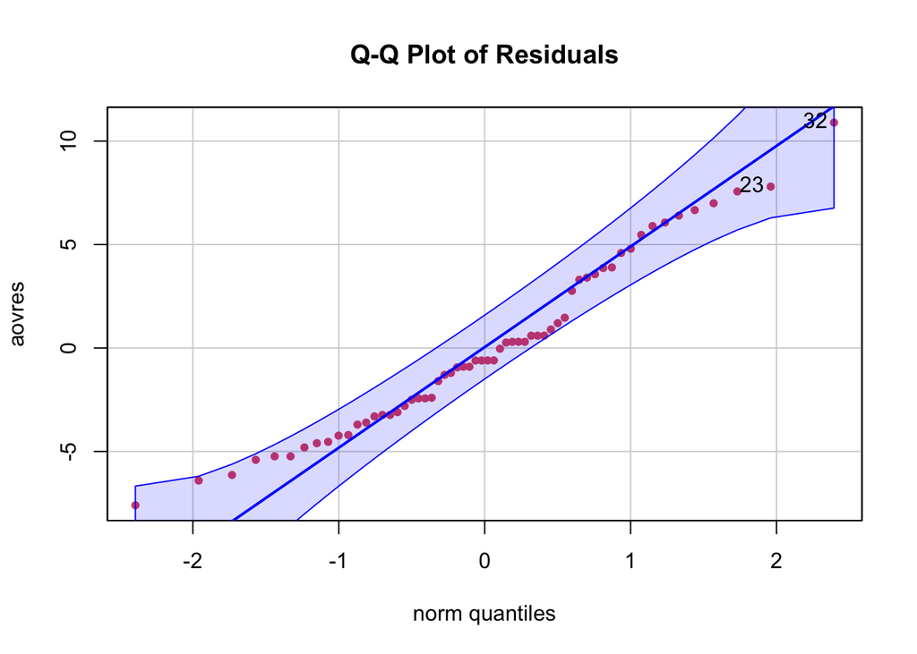

```
[1] 32 23
```

```r
aovfits <- fitted(anova_model_dose)
aovres <- residuals(anova_model_dose)
car::qqPlot(aovres, main = "Q-Q Plot of Residuals", pch = 19, col = 2, cex = 0.7)
```

```r
shapiro.test(aovres)
```

```
    Shapiro-Wilk normality test

data:  aovres
W = 0.96731, p-value = 0.1076
```

The $p$-value of 0.1076 from the Shapiro-Wilk significance test for normality of $e_{ij}$ validates the normality assumption.

Equal Variance:

Null Hypothesis: The variance of the length of odontoblasts for each level of dose is equal.

$H_0$: $\sigma_1^2 = \sigma_2^2 = \sigma_3^2$

where $\sigma_i^2$ is the variance of the length of odontoblasts for level $i$ of dose.

Alternative Hypothesis: The variance of the length of odontoblasts for each level of dose is not equal.

$H_a$: $\sigma_i^2 \neq \sigma_j^2$ for at least one pair of levels $i$ and $j$ of dose.

```r
levene_result_lawstat <- levene.test(ToothGrowth$len, factor(ToothGrowth$dose))

print(levene_result_lawstat)
```

```
    Modified robust Brown-Forsythe Levene-type test based on the absolute
    deviations from the median

data:  ToothGrowth$len
Test Statistic = 0.64573, p-value = 0.5281
```

The large $p$-value (much greater than 0.05) from the Levene significance test for equal variance validates the equal variance assumption.

```r
effects(anova_model_dose)
```

```
     (Intercept) as.factor(dose)1 as.factor(dose)2
   -145.72745337       5.04817624      48.99949234      -3.88534386

     -3.28534386       0.31465614       1.51465614       1.51465614

     -4.48534386      -2.68534386      -2.19553579      -2.19553579

     -3.49553579      -1.39553579       3.80446421      -1.39553579

     -5.09553579      -4.19553579       0.10446421      -3.19553579

     -2.33465582      -7.43465582       7.96534418      -0.43465582

      0.46534418       6.56534418       0.76534418      -4.43465582

     -2.63465582       3.56534418       5.51465614      11.81465614

      7.91465614       0.01465614       4.81465614       0.31465614

     -1.48534386      -0.28534386       6.81465614       0.01465614

      1.00446421       4.60446421       4.90446421       7.70446421

      1.30446421       6.50446421       7.10446421       2.50446421

     -4.19553579       8.60446421      -0.43465582       0.46534418

     -3.53465582      -1.43465582      -1.13465582       4.96534418

      0.46534418       1.36534418       3.46534418      -2.93465582
attr(,"assign")
[1] 0 1 1
attr(,"class")
[1] "coef"
```

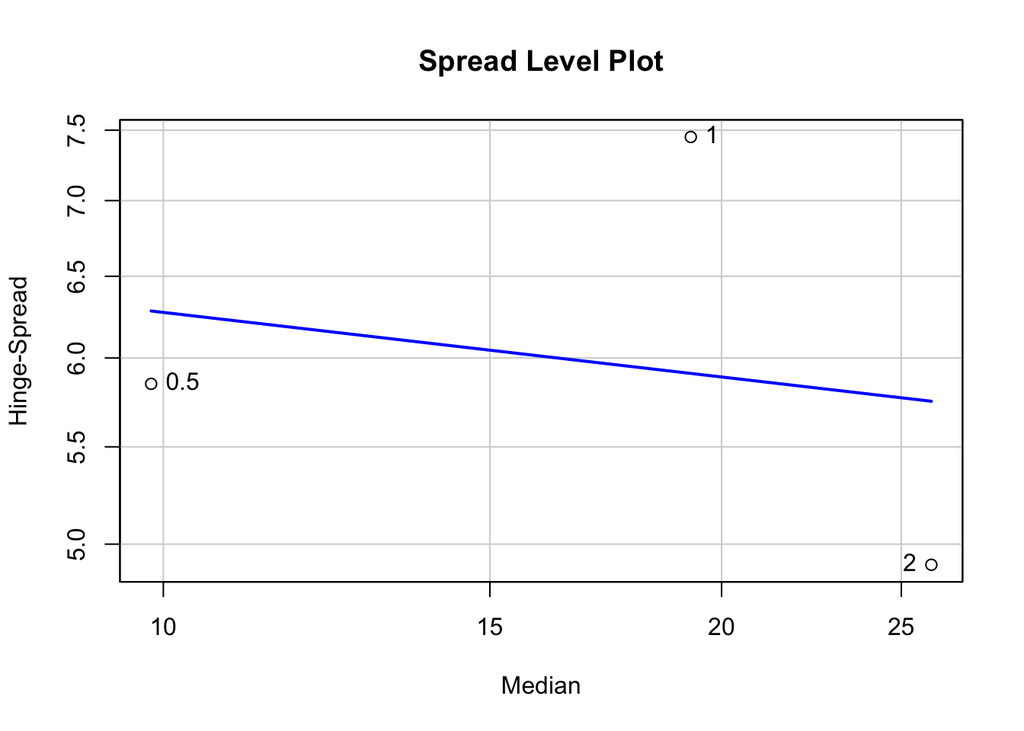

```
    LowerHinge Median UpperHinge Hinge-Spread
0.5       7.15   9.85      13.00         5.85
1        16.00  19.25      23.45         7.45
2        23.45  25.95      28.35         4.90

Suggested power transformation:  1.091292
```

```r
spreadLevelPlot(ToothGrowth$len, by=ToothGrowth$dose, main="Spread Level Plot")
```

2. Fit and interpret a one-factor ANOVA model relating the response *len* to *supp* (Factor B).

Null Hypothesis: The mean length of odontoblasts is the same for all levels of supp.

$H_0$: $\mu_1 = \mu_2$

where $\mu_i$ is the mean length of odontoblasts for level $i$ of supp.

Alternative Hypothesis: The mean length of odontoblasts is different for at least one level of supp.

$H_1$ $\mu_i \neq \mu_j$ for at least one pair of levels $i$ and $j$ of supp.

Assumptions (WILL BE VALIDATED AFTER RUNNING ANOVA MODEL):

Normality:

We assume that the length of odontoblasts for each level of supp is normally distributed.

Independence:

We assume that the length of odontoblasts for each level of supp is independent of the length of odontoblasts for the other levels of supp.

Equal Variance:

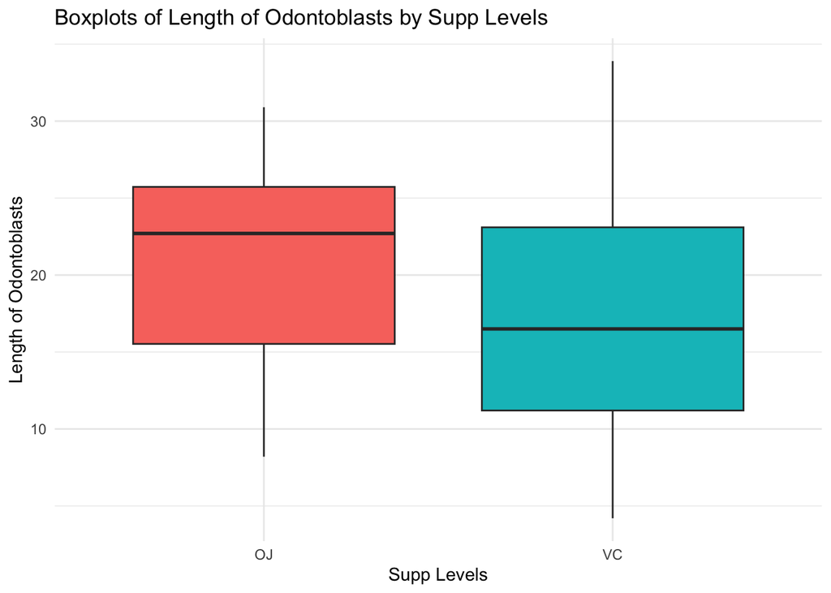

```r
# Create boxplots by supp levels using ggplot
ggplot(ToothGrowth, aes(x=as.factor(supp), y=len, fill=as.factor(supp))) +
    geom_boxplot(show.legend = FALSE) +
    labs(x="Supp Levels", y="Length of Odontoblasts") +
    theme_minimal() +
    ggtitle("Boxplots of Length of Odontoblasts by Supp Levels")
```

We assume that the variance of the length of odontoblasts for each level of supp is equal.

```r
# Fit a one-factor ANOVA model with supp as the factor
anova_model_supp <- aov(len ~ as.factor(supp), data = ToothGrowth)
summary(anova_model_supp)
```

```
                Df Sum Sq Mean Sq F value Pr(>F)
as.factor(supp)  1    205  205.35   3.668 0.0604 .
Residuals       58   3247   55.98
---
Signif. codes:  0 '***' 0.001 '**' 0.01 '*' 0.05 '.' 0.1 ' ' 1
```

Interpretation:

The output of the summary indicates that the F-value for the one-factor ANOVA model relating the response len to supp is approximately 3.67, and the associated p-value is 0.0604.

This p-value is greater than the conventional alpha level of 0.05, suggesting that there is not enough evidence to reject the null hypothesis that the means of len are equal across the different levels of supp at the 5% significance level. In other words, based on the available data, we do not have sufficient statistical evidence to conclude that the supplement type (supp) has a significant impact on the length of odontoblasts (len) in guinea pigs.

Although we do not have to validate assumptions because the test was insignificant, we will do so for completeness.

Validate Assumptions:

Normality:

Null Hypothesis: The residuals $e_{ij}$ are normally distributed.

$H_0$: $e_{ij} \sim N(0, \sigma^2)$

where $e_{ij}$ is the residual for the $j$th observation in the $i$th level of supp.

Alternative Hypothesis: The residuals $e_{ij}$ are not normally distributed.

$H_a$: $e_{ij} \nsim N(0, \sigma^2)$

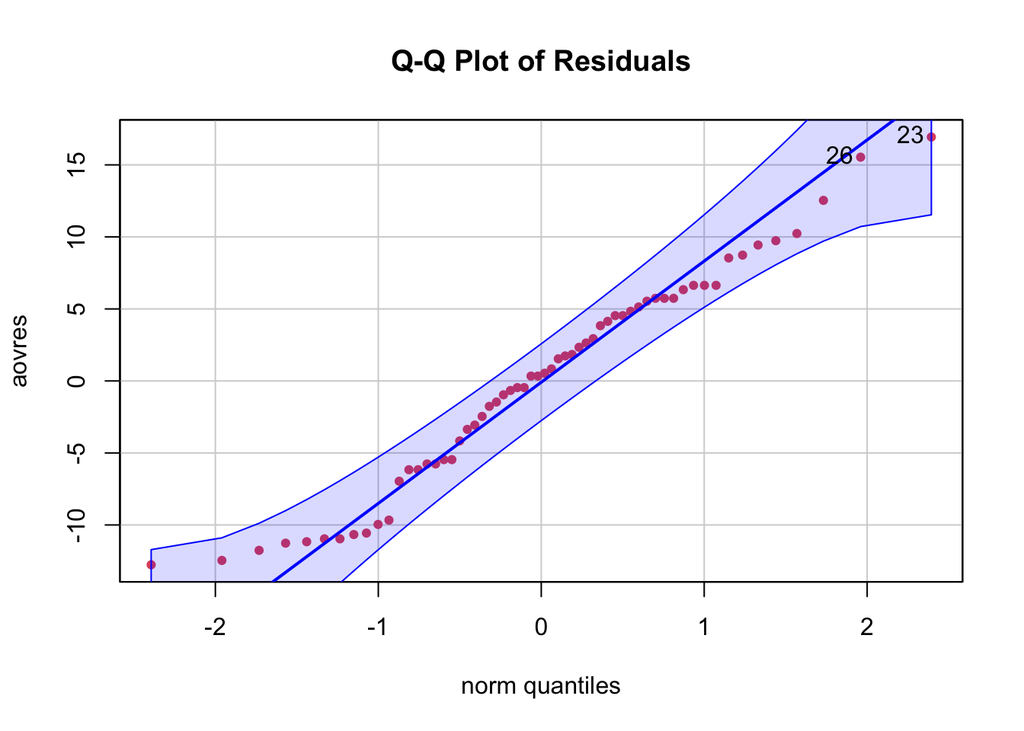

```
[1] 23 26
```

```r
aovfits <- fitted(anova_model_supp)
aovres <- residuals(anova_model_supp)
car::qqPlot(aovres, main = "Q-Q Plot of Residuals", pch = 19, col = 2, cex = 0.7)
```

```r
shapiro.test(aovres)
```

```
    Shapiro-Wilk normality test

data:  aovres
W = 0.96949, p-value = 0.1378
```

The $p$-value of 0.1378 from the Shapiro-Wilk significance test for normality of $e_{ij}$ validates the normality assumption.

Equal Variance:

Null Hypothesis: The variance of the length of odontoblasts for each level of supp is equal.

$H_0$: $\sigma_1^2 = \sigma_2^2$

where $\sigma_i^2$ is the variance of the length of odontoblasts for level $i$ of supp.

Alternative Hypothesis: The variance of the length of odontoblasts for each level of supp is not equal.

$H_a$: $\sigma_i^2 \neq \sigma_j^2$ for at least one pair of levels $i$ and $j$ of supp.

```r
levene_result_lawstat <- levene.test(ToothGrowth$len, factor(ToothGrowth$supp))

print(levene_result_lawstat)
```

```
    Modified robust Brown-Forsythe Levene-type test based on the absolute
    deviations from the median

data:  ToothGrowth$len
Test Statistic = 1.2136, p-value = 0.2752
```

The large $p$-value (much greater than 0.05) from the Levene significance test for equal variance validates the equal variance assumption.

```r
# Obtain the effects of the levels of CWP
effects(anova_model_supp)
```

```
      (Intercept) as.factor(supp)VC
    -145.72745337       14.33003838       -7.79315798       -9.29315798

      -8.69315798       -5.09315798       -3.89315798       -3.89315798

      -9.89315798       -8.09315798        1.40684202        1.40684202

       0.10684202        2.20684202        7.40684202        2.20684202

      -1.49315798       -0.59315798        3.70684202        0.40684202

       8.50684202        3.40684202       18.80684202       10.40684202

      11.30684202       17.40684202       11.60684202        6.40684202

       8.20684202       14.40684202       -4.52090739        1.77909261

      -2.12090739      -10.02090739       -5.22090739       -9.72090739

     -11.52090739      -10.32090739       -3.22090739      -10.02090739

      -0.02090739        3.57909261        3.87909261        6.67909261

       0.27909261        5.47909261        6.07909261        1.47909261

      -5.22090739        7.57909261        5.77909261        6.67909261

       2.67909261        4.77909261        5.07909261       11.17909261

       6.67909261        7.57909261        9.67909261        3.27909261
attr(,"assign")
[1] 0 1
attr(,"class")
[1] "coef"
```

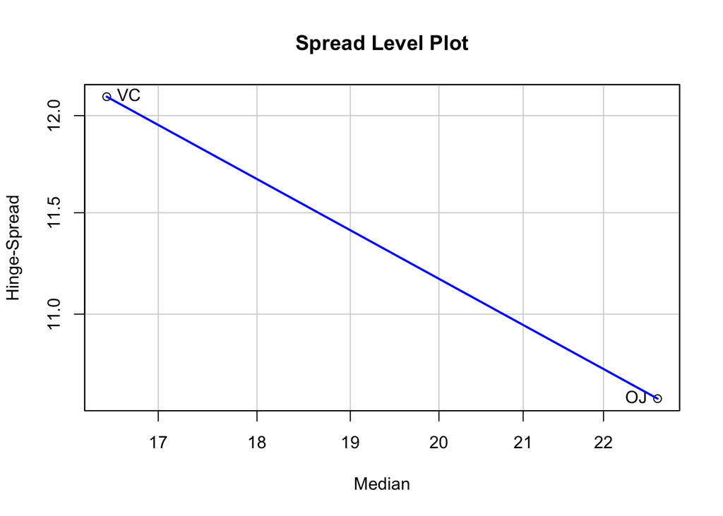

```
   LowerHinge Median UpperHinge Hinge-Spread
VC       11.2   16.5       23.3         12.1
OJ       15.2   22.7       25.8         10.6

Suggested power transformation:  1.414889
```

```r
spreadLevelPlot(ToothGrowth$len, by=ToothGrowth$supp, main="Spread Level Plot")
```

3. Fit and interpret an additive two-factor ANOVA model relating the response *len* to *dose* (Factor A) and *supp* (Factor B).

Null Hypothesis: The mean length of odontoblasts is the same for all levels of dose and supp.

$H_0$: $\mu_{11} = \mu_{12} = \mu_{21} = \mu_{22} = \mu_{31} = \mu_{32}$

where $\mu_{ij}$ is the mean length of odontoblasts for level $i$ of dose and level $j$ of supp.

Alternative Hypothesis: The mean length of odontoblasts is different for at least one level of dose and supp.

$H_1$: $\mu_{ij} \neq \mu_{kl}$ for at least one pair of levels $i$ and $j$ of dose and levels $k$ and $l$ of supp.

ASSUMPTIONS HAVE BEEN VALIDATED IN PARTS (a) AND (b).

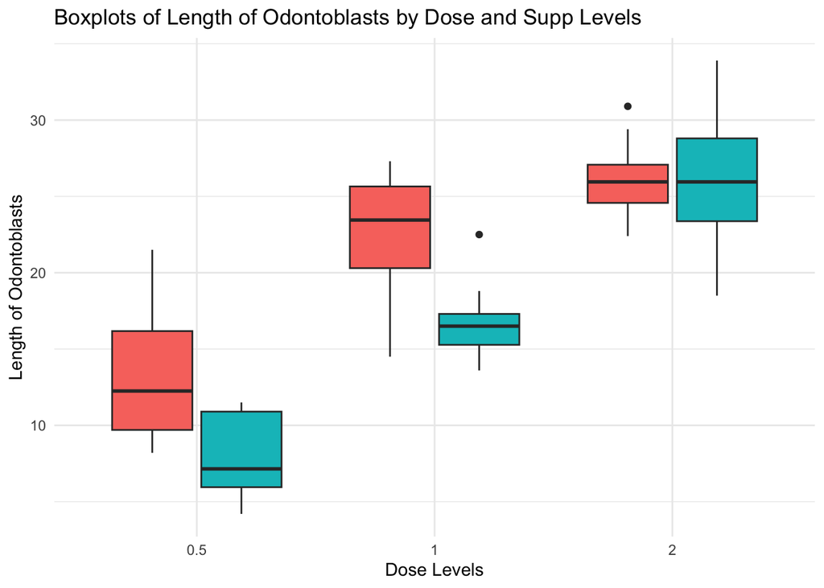

```r
# Create boxplots by dose and supp levels using ggplot
ggplot(ToothGrowth, aes(x=as.factor(dose), y=len, fill=as.factor(supp))) +
    geom_boxplot(show.legend = FALSE) +
    labs(x="Dose Levels", y="Length of Odontoblasts") +
    theme_minimal() +
    ggtitle("Boxplots of Length of Odontoblasts by Dose and Supp Levels")
```

```r
# Fit an additive two-factor ANOVA model
anova_model_additive <- aov(len ~ as.factor(dose) + as.factor(supp), data = ToothGrowth)
summary(anova_model_additive)
```

```
                Df Sum Sq Mean Sq F value   Pr(>F)
as.factor(dose)  2 2426.4  1213.2   82.81  < 2e-16 ***
as.factor(supp)  1  205.4   205.4   14.02 0.000429 ***
Residuals       56  820.4    14.7
---
Signif. codes:  0 '***' 0.001 '**' 0.01 '*' 0.05 '.' 0.1 ' ' 1
```

Interpretation: The summary of the additive two-factor ANOVA model indicates that both dose and supp are significant factors affecting the response variable len.

Dose Factor:

F-value: 82.81

p-value: < 2e-16 (extremely small)

The extremely small p-value for the dose factor suggests that there is overwhelming evidence to reject the null hypothesis that all dose level means are equal. In other words, there are significant differences in the length of odontoblasts among the different dose levels of vitamin C.

Supp Factor:

F-value: 14.02

p-value: 0.000429

The small p-value for the supp factor suggests that there is strong evidence to reject the null hypothesis that the means of len are equal across the different levels of supp. This implies that the supplement type (supp) has a significant impact on the length of odontoblasts (len) in guinea pigs when considered in conjunction with the dose levels in the additive model.

4. Fit and interpret a two-factor ANOVA model with interaction relating the response *len* to *dose* (Factor A) and *supp* (Factor B).

The null and alternative hypothesis are the same as in part (c).

ASSUMPTIONS HAVE BEEN VALIDATED IN PARTS (a) AND (b).

```r
# Fit a two-factor ANOVA model with interaction
anova_model_interaction <- aov(len ~ as.factor(dose) * as.factor(supp), data = ToothGrowth)
summary(anova_model_interaction)
```

```
                                Df Sum Sq Mean Sq F value   Pr(>F)
as.factor(dose)                  2 2426.4  1213.2  92.000  < 2e-16 ***
as.factor(supp)                  1  205.4   205.4  15.572 0.000231 ***
as.factor(dose):as.factor(supp)  2  108.3    54.2   4.107 0.021860 *
Residuals                       54  712.1    13.2
---
Signif. codes:  0 '***' 0.001 '**' 0.01 '*' 0.05 '.' 0.1 ' ' 1
```

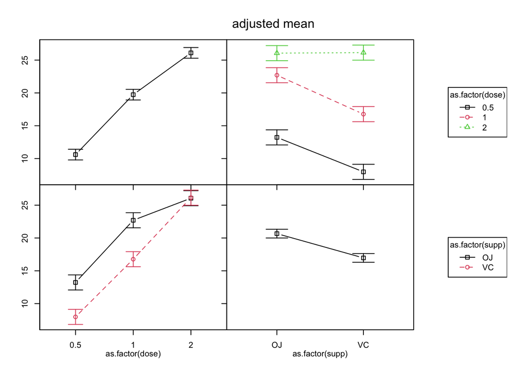

```r
library(phia)

IM <- interactionMeans(anova_model_interaction)
plot(IM)
```

Interpretation:

The output of the summary indicates the presence of main effects for both dose and supp, as well as an interaction effect between dose and supp on the response variable len.

Dose Factor:

F-value: 92.00

p-value: < 2e-16 (extremely small)

This extremely small p-value for the dose factor provides overwhelming evidence against the null hypothesis that all dose level means are equal, indicating significant differences in the length of odontoblasts among the different dose levels of vitamin C.

Supp Factor:

F-value: 15.572

p-value: 0.000231

The small p-value for the supp factor provides strong evidence against the null hypothesis that the means of len are equal across the different levels of supp. This implies that the supplement type (supp) has a significant impact on the length of odontoblasts (len) in guinea pigs.

Interaction between Dose and Supp:

F-value: 4.107

p-value: 0.021860

The interaction term between dose and supp is also significant with a p-value of 0.021860, which is less than 0.05. This suggests that the effect of dose on the length of odontoblasts is not consistent across the different levels of supp; the impact of vitamin C dose on tooth growth depends on the method of supplement delivery. The presence of a significant interaction term implies that the combined effect of dose and supp is not simply the sum of their individual effects, and the interaction between them should be considered when studying their impact on tooth growth.

5. Summarize what you learned from the analyses in (a) - (d).
- Both dose and supp have significant main effects on the length of odontoblasts.
- There is a significant interaction between dose and supp, indicating that the effect of one factor depends on the level of the other.
- While dose consistently showed a strong effect on tooth growth, the significance of supp became evident when considering it in conjunction with dose in the two-factor models.

**Q4. Open question. Not graded for credit.** Choose an application domain that interests you. Find/download an interesting data set in this domain which lends to analysis using one-factor or two-factor ANOVA analysis. Carry out a comprehensive analysis (testing assumptions, testing a suitable hypothesis, estimating effects etc.). Summarize as a report. You can share this on Discussion Board, and include on your Github page.

Overview:

The National Basketball Association (NBA) is a men’s professional basketball league in North America. The league is composed of 30 teams (29 in the United States and 1 in Canada) and is one of the four major professional sports leagues in the United States and Canada. The NBA is an active member of USA Basketball (USAB), which is recognized by FIBA (also known as the International Basketball Federation) as the national governing body for basketball in the United States. The NBA is one of the four major professional sports leagues in the United States and Canada. NBA players are the world’s best paid athletes by average annual salary per player.

```r
library(dplyr)
library(tidyverse)
library(car)

# Load the modified dataset with the 'Division' column
data <- read.csv("/Users/giovanni-lunetta/uconn_masters/stat5405/hw_4/merged_with_mapped_salaries_and_conference_df.csv")
```

Null Hypothesis: The mean team pace is the same for all divisions.

where $\mu_i$ is the mean team pace for division $i$.

Alternative Hypothesis: The mean team pace is different for at least one division.

$H_a$: $\mu_i \neq \mu_j$ for at least one pair of divisions $i$ and $j$.

Assumptions (WILL BE VALIDATED AFTER RUNNING ANOVA MODEL):

Normality:

We assume that the team pace for each division is normally distributed.

Independence:

We assume that the team pace for each division is independent of the team pace for the other divisions.

Equal Variance:

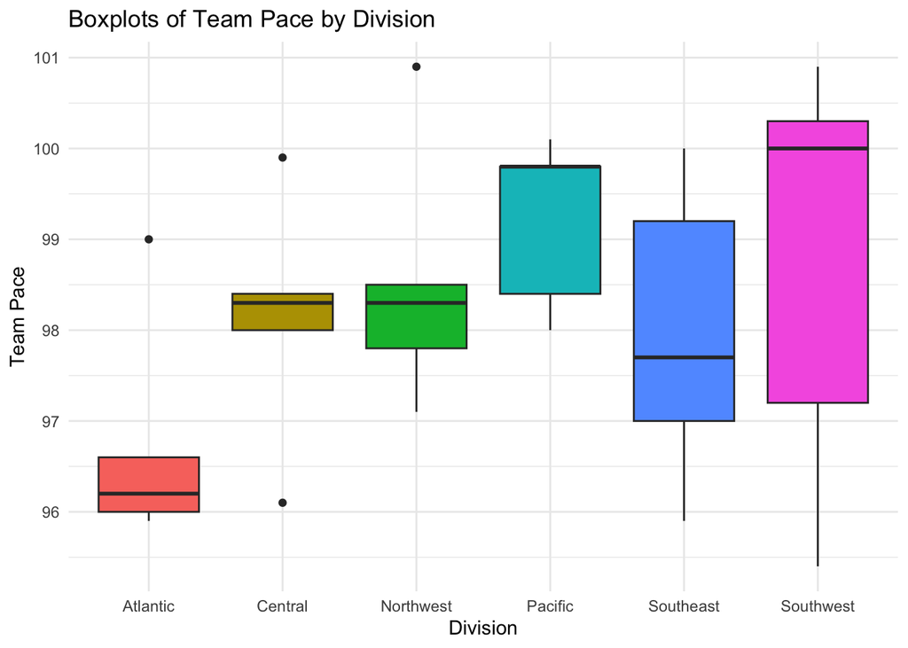

```r
# Create boxplots by division using ggplot
ggplot(data, aes(x=as.factor(Division), y=Team_Pace, fill=as.factor(Division))) +
    geom_boxplot(show.legend = FALSE) +
    labs(x="Division", y="Team Pace") +
    theme_minimal() +
    ggtitle("Boxplots of Team Pace by Division")
```

We assume that the variance of the team pace for each division is equal.

```r
# Convert Division and Conference to factors
data$Division <- as.factor(data$Division)
data$Conference <- as.factor(data$Conference)
```

```r
# Run one-way ANOVA
anova_result <- aov(Team_Pace ~ Division, data = data)

# View the summary of the ANOVA result
summary(anova_result)
```

```
            Df Sum Sq Mean Sq F value Pr(>F)
Division     5  18.23   3.646   1.482  0.233
Residuals   24  59.04   2.460
```

Interpretation:

The p-value is the probability that you obtain the observed results, or more extreme, given that the null hypothesis is true. A smaller p-value (< 0.05) usually indicates that you can reject the null hypothesis.

In this case, the p-value obtained from the one-way ANOVA is 0.233. Since this value is greater than the common alpha level of 0.05, we fail to reject the null hypothesis.

Conclusion:

Based on our analysis, there is not sufficient evidence to conclude that there is a significant difference in the mean team pace among the different divisions, at the 0.05 significance level. In other words, we do not have enough statistical evidence to say that the mean team pace is different for at least one division.

Further Remarks:

Even though there isn’t a significant difference in the mean team pace among the divisions, it could be insightful to explore other factors or variables that might affect team pace. Additionally, exploring the interactions between different variables might reveal significant effects that are not apparent when considering each variable separately.

Validating Assumptions:

Since the p-value is not less than 0.05, strictly speaking, there is no need to check the assumptions of normality and equal variance (homogeneity of variance), as we do not proceed with post hoc tests when you fail to reject the null hypothesis in ANOVA.

Next Steps:

What if there is a difference in pace between conferences (Eastern and Western)?

Null Hypothesis: The mean team pace is the same for both conferences.

$H_0$: $\mu_{Eastern} = \mu_{Western}$

where $\mu_{Eastern}$ is the mean team pace for the Eastern conference and $\mu_{Western}$ is the mean team pace for the Western conference.

Alternative Hypothesis: The mean team pace is different for the two conferences.

$H_a$: $\mu_{Eastern} \neq \mu_{Western}$

Assumptions (WILL BE VALIDATED AFTER RUNNING ANOVA MODEL):

Normality:

We assume that the team pace for each conference is normally distributed.

Independence:

We assume that the team pace for each conference is independent of the team pace for the other conference.

Equal Variance:

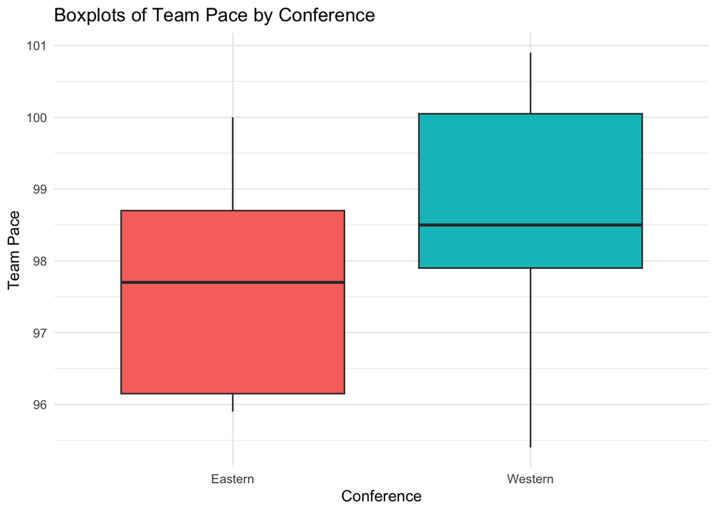

```r
# Create boxplots by conference using ggplot
ggplot(data, aes(x=as.factor(Conference), y=Team_Pace, fill=as.factor(Conference))) +
    geom_boxplot(show.legend = FALSE) +
    labs(x="Conference", y="Team Pace") +
    theme_minimal() +
    ggtitle("Boxplots of Team Pace by Conference")
```

We assume that the variance of the team pace for each conference is equal.

```r
# Run one-way ANOVA for Conference
anova_result_conference <- aov(Team_Pace ~ Conference, data = data)

# View the summary of the ANOVA result
summary(anova_result_conference)
```

```
            Df Sum Sq Mean Sq F value Pr(>F)
Conference   1  11.16  11.163   4.728 0.0383 *
Residuals   28  66.11   2.361
---
Signif. codes:  0 '***' 0.001 '**' 0.01 '*' 0.05 '.' 0.1 ' ' 1
```

Interpretation:

The p-value is the probability that you obtain the observed results, or more extreme, given that the null hypothesis is true. A smaller p-value (< 0.05) usually indicates that you can reject the null hypothesis.

In this case, the p-value obtained from the one-way ANOVA is 0.0383. Since this value is less than the common alpha level of 0.05, we reject the null hypothesis.

Conclusion:

Based on our analysis, there is sufficient evidence to conclude that there is a significant difference in the mean team pace between the two conferences, at the 0.05 significance level. In other words, we have enough statistical evidence to say that the mean team pace is different between the conferences.

Validating Assumptions:

Normality:

Null Hypothesis: The residuals $e_{ij}$ are normally distributed.

$H_0$: $e_{ij} \sim N(0, \sigma^2)$

where $e_{ij}$ is the residual for the $j$th observation in the $i$th conference.

Alternative Hypothesis: The residuals $e_{ij}$ are not normally distributed.

$H_a$: $e_{ij} \nsim N(0, \sigma^2)$

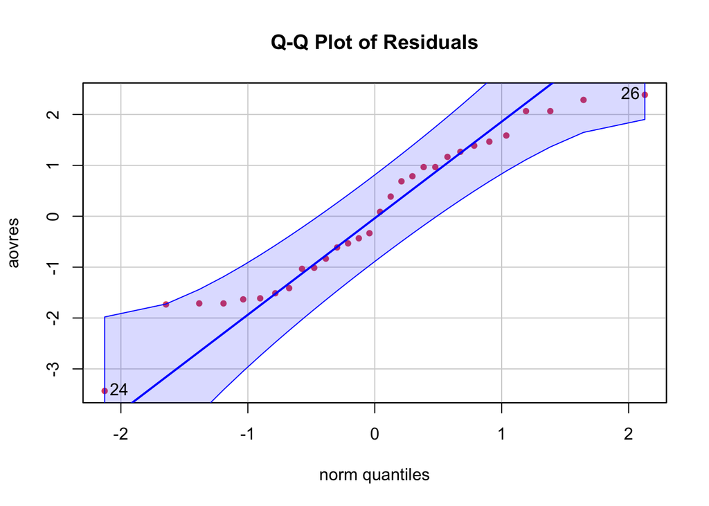

```
[1] 24 26
```

```r
aovfits <- fitted(anova_result_conference)
aovres <- residuals(anova_result_conference)
car::qqPlot(aovres, main = "Q-Q Plot of Residuals", pch = 19, col = 2, cex = 0.7)
```

```r
shapiro.test(aovres)
```

```
    Shapiro-Wilk normality test

data:  aovres
W = 0.95089, p-value = 0.1786
```

The $p$-value of 0.1786 from the Shapiro-Wilk significance test for normality of $e_{ij}$ validates the normality assumption.

Equal Variance:

Null Hypothesis: The variance of the team pace for each conference is equal.

$H_0$: $\sigma_{Eastern}^2 = \sigma_{Western}^2$

where $\sigma_{Eastern}^2$ is the variance of the team pace for the Eastern conference and $\sigma_{Western}^2$ is the variance of the team pace for the Western conference.

Alternative Hypothesis: The variance of the team pace for each conference is not equal.

$H_a$: $\sigma_{Eastern}^2 \neq \sigma_{Western}^2$

```r
levene_result_lawstat <- levene.test(data$Team_Pace, factor(data$Conference))

print(levene_result_lawstat)
```

```
    Modified robust Brown-Forsythe Levene-type test based on the absolute
    deviations from the median

data:  data$Team_Pace
Test Statistic = 0.012993, p-value = 0.9101
```

The $p$-value of 0.9101 from the Levene significance test for equal variance validates the equal variance assumption.

Overall Conclusion:

Based on our analysis, there is sufficient evidence to conclude that there is a significant difference in the mean team pace between the two conferences, at the 0.05 significance level. In other words, we have enough statistical evidence to say that the mean team pace is different between the conferences.